# Coarse SNNM: DIH Prosecutions

Kelly Kung

4/12/2022

# 1 Set Up

## 1.1 R Code

```r
#packages we need for this code file
library(ggplot2)
library(mgcv)
library(lubridate)
library(zoo)
library(tidyverse)
library(dplyr)
library(aod)
library("plot3D")
```

## 1.2 Data

```r
#read in data
main_analysis_data<-read.csv("./Data/full_data_set_11_29_21_unintentional.csv")

################################## set up data set ################################
#add the intervention dates and time period data
main_analysis_data$Intervention_First_Date<-as.Date(main_analysis_data$Intervention_First_Date)
main_analysis_data$Time_Period_Start<-as.Date(main_analysis_data$Time_Period_Start)
names(main_analysis_data)[which(colnames(main_analysis_data) == "sum_deaths")] <- "imputed_deaths"
main_analysis_data$dih_exposure <- as.numeric(main_analysis_data$Intervention_Redefined > 0)
#compute the risk of overdose death
main_analysis_data$prop_dead <- main_analysis_data$imputed_deaths/main_analysis_data$population
```

# 2 Model for Treatment Effect

## 2.1 Create Dataset

```r
#create sum of policies already enacted for treatment initiation
#create a new dataset dih_dataset for which we can make changes to
dih_dataset <- main_analysis_data
#we first create lag variables for the policies so that we know that by time t, whether the policy has been enacted
#note that we don't count what happened at time t
dih_dataset <- dih_dataset %>%
  #make sure that the data is ordered according to first state and then time period
  arrange(State, Time_Period_ID) %>%
  #group by state so that when we lag, we only lag within the state
  group_by(State) %>%
  mutate(lag_tx = lag(dih_exposure),
         lag_naloxone_pharm_yes = lag(Naloxone_Pharmacy_Yes_Redefined),
         lag_naloxone_pharm_no = lag(Naloxone_Pharmacy_No_Redefined),
         lag_medical_marijuana = lag(Medical_Marijuana_Redefined),
         lag_rec_marijuana = lag(Recreational_Marijuana_Redefined),
         lag_gsl = lag(GSL_Redefined),
         lag_pdmp = lag(PDMP_Redefined),
         lag_medicaid = lag(Medicaid_Expansion_Redefined),
         lag_intervention = lag(Intervention_Redefined))

#since we lag the variables, the entry at time 1 will be NA. Since we have start dates of the different policies, I checked to
#see which policies were enacted before Jan 1, 2000.
#if the policies were enacted before Jan 1, 2000, I impute a 1 for the first time period, otherwise a 0
dih_dataset$lag_tx[dih_dataset$Time_Period_ID == 1] <-
  dih_dataset$lag_naloxone_pharm_yes[dih_dataset$Time_Period_ID == 1] <-
  dih_dataset$lag_naloxone_pharm_no[dih_dataset$Time_Period_ID == 1] <-
  dih_dataset$lag_rec_marijuana[dih_dataset$Time_Period_ID == 1] <-
  dih_dataset$lag_gsl[dih_dataset$Time_Period_ID == 1] <-
  dih_dataset$lag_medicaid[dih_dataset$Time_Period_ID == 1] <-
  dih_dataset$lag_intervention[dih_dataset$Time_Period_ID == 1]<-0

dih_dataset$lag_medical_marijuana[dih_dataset$Time_Period_ID == 1 &
                                   dih_dataset$State %in%
                                   c("Alaska", "California", "Maine", "Oregon", "Washington")] <- 1
dih_dataset$lag_medical_marijuana[dih_dataset$Time_Period_ID == 1  &
                                   !(dih_dataset$State %in%
                                       c("Alaska", "California", "Maine", "Oregon", "Washington"))] <- 0

dih_dataset$lag_pdmp[dih_dataset$Time_Period_ID == 1  &
                                   dih_dataset$State %in%
                      c("California", "Hawaii", "Idaho", "Illinois", "Indiana",
                        "Kentucky", "Massachusetts", "Michigan", "Nevada",
                        "New York", "Oklahoma", "Pennsylvania", "Rhode Island",
                        "Texas", "Utah", "West Virginia")] <- 1
dih_dataset$lag_pdmp[dih_dataset$Time_Period_ID == 1  &
                                   !(dih_dataset$State %in%
                                       c("California", "Hawaii", "Idaho", "Illinois", "Indiana",
                                         "Kentucky", "Massachusetts", "Michigan", "Nevada",
                                         "New York", "Oklahoma", "Pennsylvania", "Rhode Island",
                                         "Texas", "Utah", "West Virginia"))] <- 0

#create a new variable that indicates the number of policies that have been enacted by time t
dih_dataset$sum_lag_policies <- dih_dataset$lag_naloxone_pharm_yes +
  dih_dataset$lag_naloxone_pharm_no +
  dih_dataset$lag_medical_marijuana +
  dih_dataset$lag_rec_marijuana +
  dih_dataset$lag_gsl +
  dih_dataset$lag_pdmp +
  dih_dataset$lag_medicaid

#impute Hawaii's treatment date as something far off in the future
dih_dataset$Intervention_First_Date[dih_dataset$State == "Hawaii"] <- as.Date("9999-01-01")
```

# 3 One Parameter Model: Binary Treatment Variable

## 3.1 Mimicking Potential Outcomes

To compute the mimicked potential outcome: $H_{s,k}(t)$ for $k \in \{7-2019, \dotsc, 7-2000 \}$ and $t < k$, we first extract $Y_{s,k}$. We then compute $\gamma_t^k = exp(\psi*(a_{s,t} - a_{s,t-1}))$. Let $t_s^*$ be the treatment time interval for state $s$. We focus on data points for which $t \leq t_s^*$ and $t<k$. This is because for the treatment initiation model, we include data points for which $t \leq t_s^*$ and we want $t<k$. We let $a_{s,t}$ be a binary variable. For these data points we are intersted in, we create the variable `hkt` which is equal to $\frac{Y_{s,k}}{exp(\psi)}$ when $k > t_s^*$ (i.e. $Y_{s,k}$ is a treated outcome) and equal to $Y_{s,k}$ when $k \leq t_s^*$ (i.e. $Y_{s,k}$ is an untreated outcome). Lastly, we combine all these datapoints together for each $k$ into a dataset to be returned to use in the treatment initiation model.

```r
compute_mimick_potential_outcome <- function(dataFrame, gamma_k_t){
  #new_df is the dataset we will return, with the new rows appended
  #we initialize it first as the input dataset df
  new_data_frame <- data.frame()

  #here, k is the time in which we observe the outcome and t is the time of the treatments
  #so we have k > t
  for(k in max(unique(dataFrame$Time_Period_ID)):2){
    #we first pull out the risk of OD at time k, so Y_k
    outcome_k_data <- dataFrame %>%
      arrange(State) %>%
      filter(Time_Period_ID == k) %>%
      dplyr::select(State, prop_dead, Intervention_First_Date, Time_Period_Start)

    #pull the treatment time period for the first treatment date
    tx_time_period_data <- dataFrame %>%
      filter(Time_Period_Start == floor_date(Intervention_First_Date, "6 months")) %>%
      select(State, Time_Period_ID)

    #rename the Time_Period_ID
    colnames(tx_time_period_data) <- c("State", "t_s")


    #merge it with outcome_k_data
    #note: we have all.x = TRUE because we want all the rows in outcome_k_data since the date
    #for Hawaii is set to year 9999, so there are no matches
    outcome_k_data_with_tx_time_period <- merge(outcome_k_data, tx_time_period_data, by = "State",
                                                all.x = TRUE)

    #set t_s for Hawaii to be 9999
    outcome_k_data_with_tx_time_period$t_s[outcome_k_data_with_tx_time_period$State == "Hawaii"] <- 9999

    #compute k - t_s^*
    outcome_k_data_with_tx_time_period$k_minus_t_s <- k - outcome_k_data_with_tx_time_period$t_s


    #compute H_k(t) given gamma_k_t:
    #here, let t^* = treatment time
    #if k <= t^*, then H_k(t) = Y_k since we havent treated yet, so doesn't affect
    #if t^* < t < k, then H_k(t) = Y_k since a_{t} - a_{t-1} = 0
    #if t <= t^* < k, then H_k(t) = Y_k/gamma_k_t
    outcome_k_data_with_tx_time_period$hkt <- ifelse(outcome_k_data_with_tx_time_period$k_minus_t_s > 0,
                                                     outcome_k_data_with_tx_time_period$prop_dead/gamma_k_t,
                                                     outcome_k_data_with_tx_time_period$prop_dead)

    # outcome_k_data <- dataFrame %>%
    #   +       arrange(State) %>%
    #   +       filter(Time_Period_ID == k) %>%
    #   +       dplyr::select(State, prop_dead, Intervention_First_Date, Time_Period_Start)
    # +
    #   +     #compute H_k(t) given gamma_k_t:
    #   +     #here, let t^* = treatment time
    #   +     #if k <= t^*, then H_k(t) = Y_k since we havent treated yet, so doesn't affect
    #   +     #if t^* < t < k, then H_k(t) = Y_k since a_{t} - a_{t-1} = 0
    #   +     #if t <= t^* < k, then H_k(t) = Y_k/gamma_k_t
    #   +     outcome_k_data$hkt <- ifelse(outcome_k_data$Time_Period_Start > outcome_k_data$Intervention_First_Date,
    #                                      +                                  outcome_k_data$prop_dead/gamma_k_t, outcome_k_data$prop_dead)


    #filter the data for which A_{s,t} = 0 and the time interval that contains the treatment time since we only need these data
    #to predict treatment initiation for the model
    #we also filter so that the t < k
    untreated_and_first_tx_date_data <- dataFrame %>%
      arrange(State, Time_Period_ID) %>%
      #filter for t <= t^* because we use these time periods to predict treatment initiation
      filter(Time_Period_Start <= Intervention_First_Date,
             #filter for t < k
             Time_Period_ID < k)

    #merge the filtered dataset with the outcome_k_data_with_tx_time_period which contains the computed H_k(t)
    untreated_and_first_tx_date_data <- merge(untreated_and_first_tx_date_data,
                                              outcome_k_data_with_tx_time_period[,c("State", "hkt", "t_s",
                                                                                    "k_minus_t_s")], by = "State")

    #compute values that may be useful
    #add k and t to the dataset and the date of k
    untreated_and_first_tx_date_data$k <- k
    untreated_and_first_tx_date_data$date_k <- unique(outcome_k_data_with_tx_time_period$Time_Period_Start)
    untreated_and_first_tx_date_data$t <- untreated_and_first_tx_date_data$Time_Period_ID


    #compute k - t
    untreated_and_first_tx_date_data$k_minus_t <- k - untreated_and_first_tx_date_data$t
    #compute indicator of whether Y_{s,k} is treated outcome
    untreated_and_first_tx_date_data$treated_outcome_indicator <- untreated_and_first_tx_date_data$date_k >
      untreated_and_first_tx_date_data$Intervention_First_Date

    #we then append the rows to the new_data_frame
    new_data_frame <- rbind(new_data_frame, untreated_and_first_tx_date_data)
  }
  new_data_frame
}
```

## 3.2 Finding $\psi$: $\gamma_t^k = exp(\psi (a_t - a_{t-1}))$

Here, we assume that the treatment effects model is given by the one parameter model:
$$\gamma_t^k = exp(\psi*(a_t - a_{t-1})),$$
where $a_t$ and $a_{t-1}$ are binary variables (for now) indicating whether there have ever been any DIH prosecution media alerts by time $t$ and $t-1$. Further, we have $k > t_s^*$.

We fit a treatment initiation model for the response `dih_exposure` which is a binary variable indicating whether the state was exposed to DIH prosecution in the media, where we use the following as predictors:

- `sum_lag_policies` is the number of other policy measures that have been enacted from time 1 until time $t-1$
- `hkt` is the computed $H_k(t)$
- `Time_Period_ID` is the linear time effect.

Recall that the `analysis_data_with_hkt` only contains the datapoints for which $t \leq t^*$. For each value $\psi$, we extract the coefficient of `hkt` from the treatment initiation model, and we find the $\psi$ that leads to a coefficient of zero. We also store a vector of `confidence_interval` which stores the values of $\psi$ if the Wald test for the coefficient of `hkt` is not statistically significant at the $alpha = 0.05$ level.

```r
#create a vector of 100 psi
# psi_grid_params <- seq(-0.1012847, -0.1012846, length.out = 100)
psi_grid_params <- seq(-.2, .1, by = 0.001)

#initialize the vector of coefficients for H(t) in treatment initiation model
coef_hkt <- rep(NA, length(psi_grid_params))
confidence_interval <- c()
for(grid_point in 1:length(psi_grid_params)){
  #statement to print the status of the for loop
  # if(grid_point%%10 == 0){print(grid_point)}
  #compute gamma_k_t given the psi_grid_params[grid_point]. Since here, the treatment is binary, we only need the value for
  #exp(psi_grid_params[grid_point])
  gamma_k_t <- exp(psi_grid_params[grid_point])

  #compute H(t) given the dataset and gamma_k_t
  analysis_data_with_hkt <- compute_mimick_potential_outcome(dih_dataset, gamma_k_t)

  #fit model for treatment initiation
  treatment_initiation_model <- glm(dih_exposure~
                       sum_lag_policies +
                       hkt +
                       Time_Period_ID,
                     data = analysis_data_with_hkt, family = "binomial")

  #store the coefficient for H_k(t)
  coef_hkt[grid_point] <- coef(treatment_initiation_model)["hkt"]

  #conduct the Wald Test for the third coefficient, which is H_k(t) here since the first coefficient is the intercept
  wald_test_results <- wald.test(vcov(treatment_initiation_model), coef(treatment_initiation_model), 3)
  #we then store the p-value and store the psi values if the p-value > 0.05
  pval <- wald_test_results$result$chi2["P"]
  if(pval > 0.05){
    confidence_interval <- rbind(confidence_interval, psi_grid_params[grid_point])
  }
}

coef_hkt[179:180]
```

```
## [1]  1.463176 -9.335244
```

```r
psi_grid_params[179:180]
```

```
## [1] -0.022 -0.021
```

```r
as.vector(confidence_interval)
```

```
##   [1] -0.140 -0.139 -0.138 -0.137 -0.136 -0.135 -0.134 -0.133 -0.132 -0.131
##  [11] -0.130 -0.129 -0.128 -0.127 -0.126 -0.125 -0.124 -0.123 -0.122 -0.121
##  [21] -0.120 -0.119 -0.118 -0.117 -0.116 -0.115 -0.114 -0.113 -0.112 -0.111
##  [31] -0.110 -0.109 -0.108 -0.107 -0.106 -0.105 -0.104 -0.103 -0.102 -0.101
##  [41] -0.100 -0.099 -0.098 -0.097 -0.096 -0.095 -0.094 -0.093 -0.092 -0.091
##  [51] -0.090 -0.089 -0.088 -0.087 -0.086 -0.085 -0.084 -0.083 -0.082 -0.081
##  [61] -0.080 -0.079 -0.078 -0.077 -0.076 -0.075 -0.074 -0.073 -0.072 -0.071
##  [71] -0.070 -0.069 -0.068 -0.067 -0.066 -0.065 -0.064 -0.063 -0.062 -0.061
##  [81] -0.060 -0.059 -0.058 -0.057 -0.056 -0.055 -0.054 -0.053 -0.052 -0.051
##  [91] -0.050 -0.049 -0.048 -0.047 -0.046 -0.045 -0.044 -0.043 -0.042 -0.041
## [101] -0.040 -0.039 -0.038 -0.037 -0.036 -0.035 -0.034 -0.033 -0.032 -0.031
## [111] -0.030 -0.029 -0.028 -0.027 -0.026 -0.025 -0.024 -0.023 -0.022 -0.021
## [121] -0.020 -0.019 -0.018 -0.017 -0.016 -0.015 -0.014 -0.013 -0.012 -0.011
## [131] -0.010 -0.009 -0.008 -0.007 -0.006 -0.005 -0.004 -0.003 -0.002 -0.001
## [141]  0.000  0.001  0.002  0.003  0.004  0.005  0.006  0.007  0.008  0.009
## [151]  0.010  0.011  0.012  0.013  0.014  0.015  0.016  0.017  0.018  0.019
## [161]  0.020  0.021  0.022  0.023  0.024  0.025  0.026  0.027  0.028  0.029
## [171]  0.030  0.031  0.032  0.033  0.034  0.035  0.036  0.037  0.038  0.039
## [181]  0.040  0.041  0.042  0.043  0.044  0.045  0.046  0.047  0.048  0.049
## [191]  0.050  0.051  0.052  0.053  0.054  0.055  0.056  0.057  0.058  0.059
## [201]  0.060  0.061  0.062  0.063  0.064  0.065  0.066  0.067  0.068  0.069
## [211]  0.070  0.071  0.072  0.073  0.074  0.075  0.076  0.077  0.078  0.079
## [221]  0.080  0.081  0.082  0.083
```

```r
#-0.022
#(-0.140, 0.083)
```

The $\psi$ that produced an $\alpha(\psi)$, where $\alpha(\psi)$ is the coefficient of $H_k(t)$ in the treatment initiation model, that is closest to 0 is -0.022. The 95% Confidence Interval is (-0.140, 0.083).

## 3.3 Checking Grid-Search

Since we can compute the $\psi$ in a one-parameter model from the unbiased estimating equation, we do so to check the grid-search value. We showed that
$$E\left(\sum_s \sum_{k=1}^{T + 1} \sum_{t = 0}^{k-1} \vec{q}{_t}^{k}(\bar{X}_{s,t}, \bar{A}_{s,t-1}) H_{s,k}(t) \mathbb{I}\{\bar{A}_{s,t-1} = \bar{0}\}({g(A}_{s,t}) - \lambda_{s,t})\right) = 0.$$
We let $\vec{q}{_t}^{k}(\bar{X}_{s,t}, \bar{A}_{s,t-1}) = 1$ and $H_{s,k}(t) = \frac{Y_{s,k}}{exp(\psi)} \mathbb{I}\{k > t_s^*\} + Y_{s,k} \mathbb{I}\{k \leq t_s^*\}$ where $t_s^*$ is the treatment time for state $s$. Furthermore, we let $g(A_{s,t}) = \mathbb{I}\{A_{s,t} > 0\}$ and $\lambda_{s,t} = p_{s,t}$, the probability of treatment. Then, we have the following:
$$\begin{align*}
0 &= \sum_s \sum_{k=1}^{T + 1} \sum_{t = 0}^{k-1} \left(\frac{Y_{s,k}}{exp(\psi)} \mathbb{I}\{k > t_s^*\} + Y_{s,k} \mathbb{I}\{k \leq t_s^*\}\right) \mathbb{I}\{\bar{A}_{s,t-1} = \bar{0}\}(\mathbb{I}\{A_{s,t} > 0\} - p_{s,t}) \\
&= \sum_s \sum_{k=1}^{T + 1} \sum_{t = 0}^{k-1} Y_{s,k}exp(-\psi) \mathbb{I}\{k > t_s^*\} \mathbb{I}\{\bar{A}_{s,t-1} = \bar{0}\}(\mathbb{I}\{A_{s,t} > 0\} - p_{s,t}) \\
&+ \sum_s \sum_{k=1}^{T + 1} \sum_{t = 0}^{k-1} Y_{s,k} \mathbb{I}\{k \leq t_s^*\} \mathbb{I}\{\bar{A}_{s,t-1} = \bar{0}\}(\mathbb{I}\{A_{s,t} > 0\} - p_{s,t}) \\
&\Rightarrow exp(-\psi) \sum_s \sum_{k=1}^{T + 1} \sum_{t = 0}^{k-1} Y_{s,k} \mathbb{I}\{k > t_s^*\} \mathbb{I}\{\bar{A}_{s,t-1} = \bar{0}\}(\mathbb{I}\{A_{s,t} > 0\} - p_{s,t}) = -\sum_s \sum_{k=1}^{T + 1} \sum_{t = 0}^{k-1} Y_{s,k} \mathbb{I}\{k \leq t_s^*\} \mathbb{I}\{\bar{A}_{s,t-1} = \bar{0}\}(\mathbb{I}\{A_{s,t} > 0\} - p_{s,t}) \\
&\Rightarrow exp(-\psi) = -\frac{\sum_s \sum_{k=1}^{T + 1} \sum_{t = 0}^{k-1} Y_{s,k} \mathbb{I}\{k \leq t_s^*\} \mathbb{I}\{\bar{A}_{s,t-1} = \bar{0}\}(\mathbb{I}\{A_{s,t} > 0\} - p_{s,t})}{\sum_s \sum_{k=1}^{T + 1} \sum_{t = 0}^{k-1} Y_{s,k} \mathbb{I}\{k > t_s^*\} \mathbb{I}\{\bar{A}_{s,t-1} = \bar{0}\}(\mathbb{I}\{A_{s,t} > 0\} - p_{s,t})} \\
&\Rightarrow \psi = - log\left(-\frac{\sum_s \sum_{k=1}^{T + 1} \sum_{t = 0}^{k-1} Y_{s,k} \mathbb{I}\{k \leq t_s^*\} \mathbb{I}\{\bar{A}_{s,t-1} = \bar{0}\}(\mathbb{I}\{A_{s,t} > 0\} - p_{s,t})}{\sum_s \sum_{k=1}^{T + 1} \sum_{t = 0}^{k-1} Y_{s,k} \mathbb{I}\{k > t_s^*\} \mathbb{I}\{\bar{A}_{s,t-1} = \bar{0}\}(\mathbb{I}\{A_{s,t} > 0\} - p_{s,t})}\right),
\end{align*}$$
where we model $p_{s,t}$ using the `sum_lag_policies` and `Time_Period_ID` for data points in which $\bar{A}_{s,t-1} = \bar{0}$. However, if the fraction is positive, then we arrive at an issue since we cannot take the log of a negative.

### 3.3.1 With Original Dataset

```r
#filter the data to fit the treatment initiation model
dih_dataset_with_past_treatment_equals_0 <- dih_dataset %>%
  # filter data so that t < t_s^* + 1
  filter(Intervention_Redefined < 1)

#fit the treatment initiation model
treatment_initiation_model <- glm(dih_exposure~
                                    sum_lag_policies +
                                    Time_Period_ID,
                                  data = dih_dataset_with_past_treatment_equals_0,
                                  family = "binomial")

#compute the p_{s,t} and add it into the dih_dataset_with_past_treatment_equals_0
prob_tx <- fitted(treatment_initiation_model)
dih_dataset_with_past_treatment_equals_0$prob_tx <- prob_tx

#compute Y_{s,k} where periods k = 1, ..., T+1 for t = 0, ..., k-1
#to do this, we can use the compute_mimick_potential_outcome() function with gamma_k_t_when_treated as 1
#we also compute an indicator of whether k > t_s^* to indicate whether it is a treated outcome or untreated outcome
data_with_observed_Ysk <- compute_mimick_potential_outcome(dih_dataset, gamma_k_t = 1)

#merge the data with Y_{s,k} and the data with the probability of treatment
observed_Ysk_and_pst <- merge(data_with_observed_Ysk,
                          dih_dataset_with_past_treatment_equals_0[,c("Time_Period_ID", "State", "prob_tx")],
                          by = c("Time_Period_ID", "State"))

#untreated outcome data to be used for numerator
untreated_outcome_data <- observed_Ysk_and_pst[observed_Ysk_and_pst$treated_outcome_indicator == FALSE,]
numerator <- sum(untreated_outcome_data$hkt*(untreated_outcome_data$dih_exposure - untreated_outcome_data$prob_tx))

#treated outcome data to be used for denominator
treated_outcome_data <- observed_Ysk_and_pst[observed_Ysk_and_pst$treated_outcome_indicator == TRUE,]
denominator <- sum(treated_outcome_data$hkt*(treated_outcome_data$dih_exposure - treated_outcome_data$prob_tx))

-log(-numerator/denominator)
```

```
## [1] -0.004318368
```

### 3.3.2 With Stacked Dataset

```r
#compute Y_{s,k} where periods k = 1, ..., T+1 for t =0, ..., k-1
#to do this, we can use the compute_mimick_potential_outcome() function with gamma_k_t_when_treated as 1
#we also compute an indicator of whether k > t_s^* to indicate whether it is a treated outcome or untreated outcome
stacked_data_with_observed_Ysk <- compute_mimick_potential_outcome(dih_dataset, gamma_k_t = 1)

treatment_initiation_model_stacked_data <- glm(dih_exposure~
                                    sum_lag_policies +
                                    Time_Period_ID,
                                  data = data_with_observed_Ysk,
                                  family = "binomial")
#store the p_{s,t}
stacked_data_with_observed_Ysk$prob_tx <- fitted(treatment_initiation_model_stacked_data)

#untreated outcome data to be used for numerator
untreated_outcome_stacked_data <- stacked_data_with_observed_Ysk[stacked_data_with_observed_Ysk$treated_outcome_indicator == FALSE,]
numerator_stacked <- sum(untreated_outcome_stacked_data$hkt*(untreated_outcome_stacked_data$dih_exposure -
                                                       untreated_outcome_stacked_data$prob_tx))

#treated outcome data to be used for denominator
treated_outcome_stacked_data <- stacked_data_with_observed_Ysk[stacked_data_with_observed_Ysk$treated_outcome_indicator == TRUE,]
denominator_stacked <- sum(treated_outcome_stacked_data$hkt*(treated_outcome_stacked_data$dih_exposure -
                                                       treated_outcome_stacked_data$prob_tx))

-log(-numerator_stacked/denominator_stacked)
```

```
## [1] -0.02186427
```

# 4 Two Parameter Model: Binary Treatment

## 4.1 Mimicking Potential Outcomes

To compute the mimicked potential outcome: $H_{s,k}(t)$ for $k \in \{7-2019, \dotsc, 7-2000 \}$ and $t < k$, we first extract $Y_{s,k}$. We then compute $\gamma_t^k = exp(\psi_1*(a_t - a_{t-1}) + \psi_2*(a_t - a_{t-1})*(k-t_s^*))$. Let $t_s^*$ be the treatment time interval for state $s$. We focus on data points for which $t \leq t_s^*$ and $t<k$. This is because for the treatment initiation model, we include data points for which $t \leq t_s^*$ and we want $t<k$. We let $a_{s,t}$ be a binary variable. For these data points we are interested in, we create the variable `hkt` which is equal to $\frac{Y_{s,k}}{exp(\psi_1 + \psi_2(k-t_s^*))}$ when $k > t_s^*$ (i.e. $Y_{s,k}$ is a treated outcome) and equal to $Y_{s,k}$ when $k \leq t_s^*$ (i.e. $Y_{s,k}$ is an untreated outcome). Lastly, we combine all these datapoints together for each $k$ into a dataset to be returned to use in the treatment initiation model.

```r
compute_mimick_potential_outcome_two_parameter_model <- function(dataFrame, psi_1, psi_2){
  #new_df is the dataset we will return, with the new rows appended
  #we initialize it first as the input dataset df
  new_data_frame <- data.frame()

  #here, k is the time in which we observe the outcome and t is the time of the treatments
  #so we have k > t
  for(k in max(unique(dataFrame$Time_Period_ID)):2){
    #we first pull out the risk of OD at time k, so Y_k
    outcome_k_data <- dataFrame %>%
      arrange(State) %>%
      filter(Time_Period_ID == k) %>%
      dplyr::select(State, prop_dead, Intervention_First_Date, Time_Period_Start)

    #pull the treatment time period for the first treatment date
    tx_time_period_data <- dataFrame %>%
      filter(Time_Period_Start == floor_date(Intervention_First_Date, "6 months")) %>%
      select(State, Time_Period_ID)

    #rename the Time_Period_ID
    colnames(tx_time_period_data) <- c("State", "t_s")

    #merge it with outcome_k_data
    #note: we have all.x = TRUE because we want all the rows in outcome_k_data since the date
    #for Hawaii is set to year 9999, so there are no matches
    outcome_k_data_with_tx_time_period <- merge(outcome_k_data, tx_time_period_data, by = "State",
                                                all.x = TRUE)

    #set t_s for Hawaii to be 9999
    outcome_k_data_with_tx_time_period$t_s[outcome_k_data_with_tx_time_period$State == "Hawaii"] <- 9999

    #compute k - t_s^*
    outcome_k_data_with_tx_time_period$k_minus_t_s <- k - outcome_k_data_with_tx_time_period$t_s

    #compute H_k(t) given psi_1 and psi_2:
    #here, let t^* = treatment time
    #if k <= t^*, then H_k(t) = Y_k since we havent treated yet, so doesn't affect
    #if t^* < t < k, then H_k(t) = Y_k since a_{t} - a_{t-1} = 0
    #if t <= t^* < k, then H_k(t) = Y_k/exp(psi_1 + psi_2*(k-t_s^*))
    outcome_k_data_with_tx_time_period$hkt <- ifelse(outcome_k_data_with_tx_time_period$k_minus_t_s > 0,
                                 outcome_k_data_with_tx_time_period$prop_dead/
                                   (exp(psi_1 + psi_2*(outcome_k_data_with_tx_time_period$k_minus_t_s))),
                                 outcome_k_data_with_tx_time_period$prop_dead)



    #filter the data for which A_{s,t} = 0 and the time interval that contains the treatment time since we only need these data
    #to predict treatment initiation for the model
    #we also filter so that the t < k
    untreated_and_first_tx_date_data <- dataFrame %>%
      arrange(State, Time_Period_ID) %>%
      #filter for t <= t^* because we use these time periods to predict treatment initiation
      filter(Time_Period_Start <= Intervention_First_Date,
             #filter for t < k
             Time_Period_ID < k)

    #merge the filtered dataset with the outcome_k_data which contains the computed H_k(t)
    untreated_and_first_tx_date_data <- merge(untreated_and_first_tx_date_data,
                                              outcome_k_data_with_tx_time_period[,c("State", "hkt", "k_minus_t_s",
                                                                                 "t_s")], by = "State")

    #store k and t
    untreated_and_first_tx_date_data$k <- k
    untreated_and_first_tx_date_data$t <- untreated_and_first_tx_date_data$Time_Period_ID
    untreated_and_first_tx_date_data$date_k <- unique(outcome_k_data$Time_Period_Start)

    #compute k - t
    untreated_and_first_tx_date_data$k_minus_t <- untreated_and_first_tx_date_data$k - untreated_and_first_tx_date_data$t

    #we then append the rows to the new_data_frame
    new_data_frame <- rbind(new_data_frame, untreated_and_first_tx_date_data)
  }
  new_data_frame
}
```

## 4.2 Finding $\psi = (\psi_1, \psi_2)$: $\gamma_t^k = exp(\psi_1 (a_t - a_{t-1}) + \psi_2(a_t - a_{t-1})(k - t_s^*))$

Here, we assume that the treatment effects model is given by the two parameter model:
$$\gamma_t^k = exp(\psi_1*(a_t - a_{t-1}) + \psi_2 *(a_t - a_{t-1})*(k-t_s^*)),$$
where $a_t$ and $a_{t-1}$ are binary variables (for now) indicating whether there have ever been any DIH prosecution media alerts by time $t$ and $t-1$ and $k - t_s^*$ indicates the length of treatment. Further, we have $k > t_s^*$.

We fit a treatment initiation model for the response `dih_exposure` which is a binary variable indicating whether the state was exposed to DIH prosecution in the media, where we use the following as predictors:

- `sum_lag_policies` is the number of other policy measures that have been enacted from time 1 until time $t-1$
- `hkt` is the computed $H_k(t)$
- `hkt*sum_lag_policies` is the interaction between the $H_k(t)$ and the number of policy measures that have been enacted from time 1 until time $t-1$
- `Time_Period_ID` is the linear time effect.

Recall that the `analysis_data_with_hkt` only contains the datapoints for which $t \leq t^*$. For each value $\psi$, we extract the coefficient of `hkt` from the treatment initiation model, and we find the $\psi$ that leads to a coefficient of zero. We also store a vector of `confidence_interval` which stores the values of $\psi$ if the Wald test for the coefficient of `hkt` and `hkt*sum_lag_policies` are not statistically significant at the $alpha = 0.05$ level.

Hence, we first fit a logistic regression model to predict $p_{s,t}$. Then, we use grid search to find a value a $\psi_2$ (and therefore, a value for $\psi_1$) such that the coefficients of `hkt` and `hkt:sum_lag_policies` are both zero.

```r
#solving for psi_1 from unbiased estimating equations, we can write psi_1 as a function of psi_2
compute_psi_1 <- function(psi_2, untreated_data, treated_data){
  #compute psi_1
  numerator <- sum(untreated_data$hkt*(untreated_data$dih_exposure - untreated_data$prob_tx))
  denominator <- sum(treated_data$hkt*exp(-psi_2*treated_data$k_minus_t_s)*(treated_data$dih_exposure - treated_data$prob_tx))

  psi_1 <- -log(-numerator/denominator)
  return(psi_1)

}
```

## 4.3 Stacked Data to Compute Intervention Probability

```r
#stacked data
#only need to run this once, so don't need to put it into the psi_1 computation function
#first extract Y_{s,k} for the appropriate k = 40, ..., 2 for each t = 0, ..., k-1
stacked_observed_Ysk <- compute_mimick_potential_outcome(dih_dataset, gamma_k_t = 1)

#predict treatment initiation
treatment_initiation_model_stacked <- glm(dih_exposure~
                                            sum_lag_policies +
                                            Time_Period_ID,
                                          data = stacked_observed_Ysk,
                                          family = "binomial")
stacked_observed_Ysk$prob_tx <- fitted(treatment_initiation_model_stacked)

#filter to datapoints where k > t_s$* and where k <= t_s^*
stacked_untreated_data <- stacked_observed_Ysk[stacked_observed_Ysk$treated_outcome_indicator == FALSE,]
stacked_treated_data <- stacked_observed_Ysk[stacked_observed_Ysk$treated_outcome_indicator == TRUE,]

psi_grid_params_psi_2_stacked <- seq(-.02, .03, length.out = 500)
psi_grid_params_psi_1_stacked <- sapply(psi_grid_params_psi_2_stacked, function(psi_2){compute_psi_1(psi_2,
                                                                                             stacked_untreated_data,
                                                                                             stacked_treated_data)})

#################################

#initialize the vector of coefficients for H(t) in treatment initiation model
coef_hkt <- rep(NA, length(psi_grid_params_psi_2_stacked))
coef_hkt_sum_policy <- rep(NA, length(psi_grid_params_psi_2_stacked))
confidence_interval <- data.frame()


for(grid_point in 1:length(psi_grid_params_psi_2_stacked)){
  #statement to print the status of the for loop
  # if(grid_point%%10 == 0){print(grid_point)}

  #some psi_1 is NaN so we don't compute for those
  if(!is.nan(psi_grid_params_psi_1_stacked)){
    #compute H(t) given the dataset and gamma_k_t_when_treated
    analysis_data_with_hkt <- compute_mimick_potential_outcome_two_parameter_model(dih_dataset,
                                                                                   psi_grid_params_psi_1_stacked[grid_point],
                                                                                   psi_grid_params_psi_2_stacked[grid_point])

    #fit model for treatment initiation
    treatment_initiation_model <- glm(dih_exposure~
                                        sum_lag_policies +
                                        hkt +
                                        Time_Period_ID +
                                        hkt*sum_lag_policies,
                                      data = analysis_data_with_hkt, family = "binomial")

    #store the coefficient for H_k(t)
    coef_hkt[grid_point] <- coef(treatment_initiation_model)["hkt"]
    coef_hkt_sum_policy[grid_point] <- coef(treatment_initiation_model)["sum_lag_policies:hkt"]


    #don't do 95% CI yet -- wait until we figure out how to get psi_1, psi_2
    # #conduct the Wald Test for the third coefficient, which is H_k(t) here since the first coefficient is the intercept
    wald_test_results <- wald.test(vcov(treatment_initiation_model), coef(treatment_initiation_model), Terms = c(3,5))
    # #we then store the p-value and store the psi values if the p-value > 0.05
    pval <- wald_test_results$result$chi2["P"]
    if(pval > 0.05){
      confidence_interval <- rbind(confidence_interval, c(psi_grid_params_psi_1_stacked[grid_point],
                                                          psi_grid_params_psi_2_stacked[grid_point]))
    }
  }
}

colnames(confidence_interval) <- c("psi_1", "psi_2")

#stacked data
#psi_1 = -0.078, 95% CI: (-0.759, 0.293)
#psi_2 = 0.002, 95% CI:(-0.012, 0.027)

coef_hkt[221:222]
```

```
## [1]  3.771338 -3.934676
```

```r
coef_hkt_sum_policy[221:222]
```

```
## [1] -3.894518  4.059625
```

```r
psi_grid_params_psi_1_stacked[221:222]
```

```
## [1] -0.07698033 -0.07968288
```

```r
psi_grid_params_psi_2_stacked[221:222]
```

```
## [1] 0.002044088 0.002144289
```

```r
confidence_interval[1,]
```

```
##       psi_1       psi_2
## 1 0.2930173 -0.01168337
```

```r
confidence_interval[nrow(confidence_interval),]
```

```
##          psi_1      psi_2
## 388 -0.7592186 0.02709419
```

The $\psi_1$ and $\psi_2$ that solves the unbiased estimating equations are $\psi_1 = -0.078$ with 95% CI = (-0.759, 0.293) and $\psi_2 = 0.002$ with 95% CI = (-0.012, 0.027).

We use the values of $\psi_1$ and $\psi_2$ to check whether the unbiased estimating equations are equal to 0.

### 4.3.1 Check Unbiased Estimating Equation

```r
psi_1_sol <- -0.07830036
psi_2_sol <- 0.002093131

sum(stacked_untreated_data$hkt*(stacked_untreated_data$dih_exposure - stacked_untreated_data$prob_tx)) +
  sum(stacked_treated_data$hkt/(exp(psi_1_sol + psi_2_sol*(stacked_treated_data$k_minus_t_s)))*(
    stacked_treated_data$dih_exposure - stacked_treated_data$prob_tx
  ))
```

```
## [1] -7.876693e-08
```

### 4.3.2 Plot the $\psi_1$ and $\psi_2$

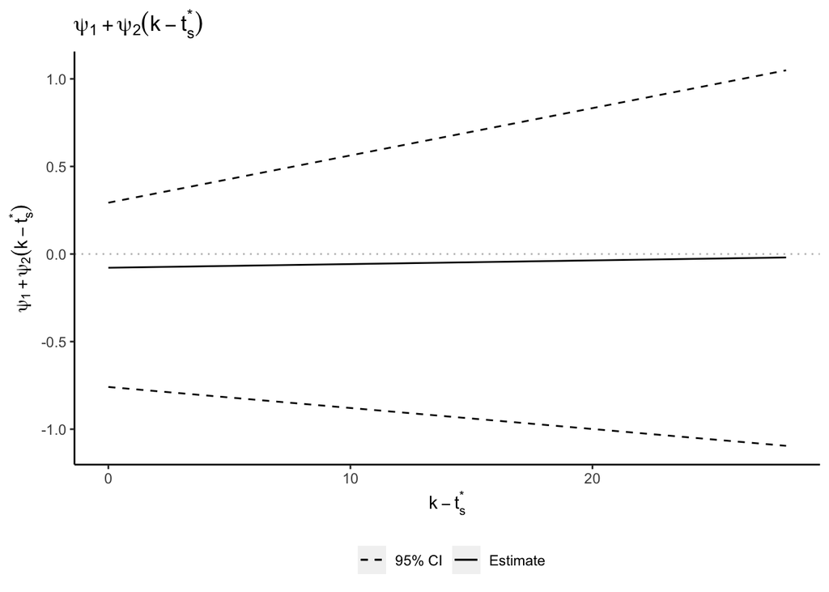

```r
total_psi_effect <- data.frame(time = 0:28,
                               sum_psi = psi_1_sol + psi_2_sol*c(0:28),
                               sum_psi_lb = -0.759 -0.012*c(0:28),
                               sum_psi_ub = 0.293 + 0.027*c(0:28))

ggplot(total_psi_effect, aes(x = time)) +
  geom_line(aes(y = sum_psi, linetype = "Estimate")) +
  geom_line(aes(y = sum_psi_lb, linetype = "95% CI")) +
  geom_line(aes(y = sum_psi_ub, linetype = "95% CI"))+
  scale_linetype_manual(values = c("dashed", "solid")) +
  labs(linetype = "",
       x = expression(k - t[s]^`*`),
       y = expression(psi[1] + psi[2](k-t[s]^`*`)),
       title = expression(psi[1] + psi[2](k-t[s]^`*`))) +
  theme(panel.grid.major = element_blank(), panel.grid.minor = element_blank(),
        panel.background = element_blank(), axis.line = element_line(colour = "black"),
        legend.position = "bottom") +
  geom_hline(aes(yintercept = 0), color = "grey", linetype = "dotted")
```